# Fifth Week: Bootstrap and Resampling Methods

Nonparametric Hypothesis tests

Mohammadmahdi Faryabi - STD-ID: 93101951

2018-03-16 02:45:19

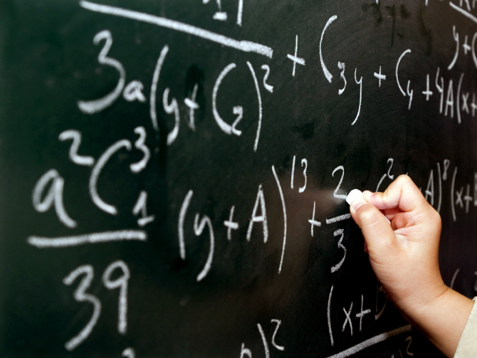

> Loading required packages and libraries.

```r
library(readr)
library(dplyr)
library(tidyr)
library(coin)
```

```r
library(highcharter)
library(magrittr)
library(ggplot2)
library(ggmosaic)
```

> لطفا با سوالات زیر پاسخ دهید. در همه سوالات سطح دقت را ۹۵ درصد در نظر بگیرید.

۱. شرکتی میخواهد تحقیق کند آیا درآمد نمایندگی های آن یکسان است. برای بررسی این موضوع هشت نمایندگی به طور تصادفی انتخاب شده اند که به ترتیب میزان فروش آنها عبارت است از 102, 300, 102, 100, 205, 105, 71 , 92. با توجه به داده آیا عملکرد نمایندگی ها یکسان است؟

> I’ve used Kolmogorov-Smirnov non-parametric hypothesis test.  
> This test compares two samples assuming thy have the same pdf or tests a sample versus a reference pdf.  
> I’ve uesd this test via branch sellings data against a discrete 8 * (1/8) pdf and a normal pdf (ok I know this test is quiet non-parametric but it is likely for branch sellings data to behave ‘normally’. Any way we can ignore this second test and be good to go :)  
> It’s also possible to do this test using chi squared goodness of fit test and also claim the same result.  
> Very low p-values indicate that we can reject null hypothesis that the stores are selling products the same in terms of selling stats.  
> These tests are non-parametric and are suitable for when we dont have much data!

```r
############################################################################################################
# Q1

stores <- c(102, 300, 102, 100, 205, 105, 71, 92)
#1
ks.test(stores, rep(1/8, 8))
```

```
##
##  Two-sample Kolmogorov-Smirnov test
##
## data:  stores and rep(1/8, 8)
## D = 1, p-value = 0.0006709
## alternative hypothesis: two-sided
```

```r
#2
ks.test(stores, 'pnorm')
```

```
##
##  One-sample Kolmogorov-Smirnov test
##
## data:  stores
## D = 1, p-value = 2.251e-07
## alternative hypothesis: two-sided
```

```r
#3
chisq.test(stores, p = rep(1/8, 8))
```

```
##
##  Chi-squared test for given probabilities
##
## data:  stores
## X-squared = 314.74, df = 7, p-value < 2.2e-16
```

۲. آمار فروش شرکتی در دو نوع شعبه سنتی و مدرن در زیر آمده است:

Classical stores: 50, 50, 60, 70, 75, 80, 90, 85

Modern stores: 55, 75, 80, 90, 105, 65

آیا تفاوتی در عملکرد دو نوع شعبه وجود دارد؟

> I’ve used Fisher-Pitman’s Permutation test and also Wilcoxon rank test which ranks the data in groups and works with ranks instead of the actual data to manage data outliers.  
> The resultig p-value is high and ot is not in confidence hypothesis rejection range.  
> So the null hypothesis that performance of the two kinds of branches is the same cannot be rejected.

```r
############################################################################################################
# Q2

q2_classical <- c(50, 50, 60, 70, 75, 80, 90, 85)
q2_modern <- c(55, 75, 80, 90, 105, 65)


data.frame(sellings = c(q2_classical, q2_modern), type = c(rep('CLASSIC', 8), rep('MODERN', 6))) -> q2_full_data

coin::oneway_test(sellings~type, data=q2_full_data, distribution="exact")
```

```
##
##  Exact Two-Sample Fisher-Pitman Permutation Test
##
## data:  sellings by type (CLASSIC, MODERN)
## Z = -0.94426, p-value = 0.3803
## alternative hypothesis: true mu is not equal to 0
```

```r
oldwarn <- getOption('warn')
options(warn = -1)
wilcox.test(sellings~type, data=q2_full_data, distribution="exact")
```

```
##
##  Wilcoxon rank sum test with continuity correction
##
## data:  sellings by type
## W = 17.5, p-value = 0.4366
## alternative hypothesis: true location shift is not equal to 0
```

```r
options(warn = oldwarn)
```

۳. اطلاعات حسابداری ۱۵ شعبه که به صورت تصادفی انتخاب شده اند به شرح زیر است:

509, 517, 502, 629, 830, 911, 847, 803, 727, 853, 757, 730, 774, 718, 904

شرکت مذکور برای ارتقای فروش خود یک طرح تبلیغاتی جدید را اجرا میکند. پس از طرح جدید نتایج عملکرد شعبه ها به صورت زیر اندازه گیری شده است

517, 508, 523, 730, 821, 940, 818, 821, 842, 842, 709, 688, 787, 780, 901

آیا تبلیغات جدید عملکرد فروش را بالا برده است؟

> I,ve uesd paired t-test and paired sogned ranked wilcoxon rank tests. this tests challenge measured data relevences with respeect to paired data information.  
> The null hypothesis is that the new branch performance is the same as the old branch performance.  
> Due to high p-value of the tests this hypothesis cannot be rejected.  
> In another words the advertisments may have had no effects at all!

```r
############################################################################################################
# Q3

data.frame(
  before = c(509, 517, 502, 629, 830, 911, 847, 803, 727, 853, 757, 730, 774, 718, 904),
  after  = c(517, 508, 523, 730, 821, 940, 818, 821, 842, 842, 709, 688, 787, 780, 901)
  ) %>% mutate(index = 1:n()) -> q3_full_data

q3_full_data %$% wilcox.test(.$before, .$after, paired = TRUE)
```

```
##
##  Wilcoxon signed rank test with continuity correction
##
## data:  .$before and .$after
## V = 45.5, p-value = 0.4263
## alternative hypothesis: true location shift is not equal to 0
```

```r
q3_full_data %$% t.test(.$before, .$after, paired = TRUE)
```

```
##
##  Paired t-test
##
## data:  .$before and .$after
## t = -1.1814, df = 14, p-value = 0.2571
## alternative hypothesis: true difference in means is not equal to 0
## 95 percent confidence interval:
##  -40.54261  11.74261
## sample estimates:
## mean of the differences
##                   -14.4
```

```r
q3_full_data %>% gather(after, before, key = 'when', value = 'score') %>%
  hchart(type = 'column', hcaes(x = index, y = score, group = when))
```

[interactive chart not shown]

۴. محصولی در سه رنگ سفید آبی و قرمز تولید شده است. پنج شعبه ار فروشگاه سازنده محصول به صورت تصادفی انتخاب شده و اطلاعات فروش آنها در زیر آمده است.

| Store | White | Blue | Red |
| --- | --- | --- | --- |
| 1. | 510 | 925 | 730 |
| 2. | 720 | 735 | 745 |
| 3. | 930 | 753 | 875 |
| 4. | 754 | 685 | 610 |
| 5. | 105 |  |  |

با توجه به داده های بالا آیا رنگی خاص در میزان فروش محصولات تاثیر دارد؟

> I’ve used friedman non parameteric chi-squared rank sum tests for this question. This test adds rank sums in each group; thus if rank sums are identical in each group then the p-value will be equal to 1!  
> In this case the rank sums are equal! hence p-value is 1 and we can say that color factor has had no effect in product sellings.  
> The symmetric form factor of mosaic diagram also proves that sellings are well distributed among colors.

```r
############################################################################################################
# Q4

q4_data <- data.frame(row.names = 1:5,
           White = c(510, 720, 930, 754, 105),
           Blue  = c(925, 735, 753, 685, NA ),
           Red   = c(730, 745, 875, 610, NA ))

q4_data %>% as.matrix() %>% friedman.test()
```

```
##
##  Friedman rank sum test
##
## data:  .
## Friedman chi-squared = 0, df = 2, p-value = 1
```

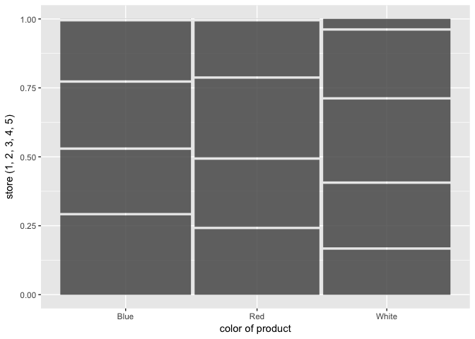

```r
q4_data %>% mutate(store_index = rownames(.)) %>%
  gather(White, Blue, Red, key = 'color', value = 'sellings') %>%
  ggplot() + geom_mosaic(aes(x = product(store_index, color), weight = sellings)) +
  labs(x = 'color of product', y = 'store (1, 2, 3, 4, 5)')
```

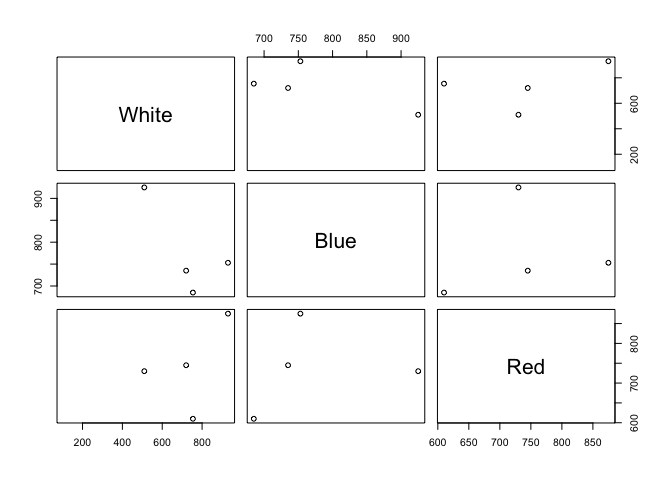

```r
q4_data %>% plot()
```

۵. یک موسسه نظرسنجی نظرات مردم در مورد رضایت از یک محصول که در ماه های فروردین اردیبهشت خرداد و تیر که از طریق تلویزیون تبلیغ شده است را مورد ارزیابی قرار می دهد.این کار بدین صورت است از افرادی در ماه اول سوال پرسیده می شود و در ماه آینده نیز از همان فرد سوال می شود که آیا از محصول مذکور راضی هستی یا خیر. با توجه به داده ایی که در پیوست تمرین آمده است آیا تبلیغات تاثیر مثبتی در افزایش رضایت مردم داشته است؟

> I’ve used friedman non parameteric chi-squared rank sum tests for this question.  
> The null hypothesis asserts that the advertisements has had no effect on people’s satisfaction  
> Due to high p-values resulted from the test, we cannot reject the null hypothesis.  
> So advertisements may have actually had no effect on people’s satisfactions at all!

```r
############################################################################################################
# Q5

q5_data <- read_csv('data/tv.csv')
q5_data %>% as.matrix() %>% friedman.test()
```

```
##
##  Friedman rank sum test
##
## data:  .
## Friedman chi-squared = 1.2, df = 3, p-value = 0.753
```

۶. شرکتی در حال تحقیق بر روی این موضوع است که آیا جمعیت شهر تاثیری در نوع میزان مصرف محصولات شرکت دارد. با توجه به داده زیر این موضوع را تحقیق کنید؟

| City size |  | Frequency of service usage |  |
| --- | --- | --- | --- |
|  | Always | Sometime | Never |
| Small | 151 | 252 | 603 |
| Medium | 802 | 603 | 405 |
| Large | 753 | 55 | 408 |

> I’ve used non-parametric Pearson’s chi-squared test for this questin.  
> The null hypothesis is that city size has had no effect on product usages.  
> Resulting test p-values are small and way inside our confidence interval.  
> So it’s possible to say that the null hypothesis is wrong and city size has indeed an effect on product usage.  
> Mosaic chart’s asymeetric form also helps proving this point!

```r
############################################################################################################
# Q6

data.frame(Always = c(151, 802, 753), Sometimes = c(252, 603, 55), Never = c(603, 405, 408),
                      row.names = c('Small', 'Medium', 'Large')) -> q6_full_data

q6_full_data %>% chisq.test()
```

```
##
##  Pearson's Chi-squared test
##
## data:  .
## X-squared = 821.31, df = 4, p-value < 2.2e-16
```

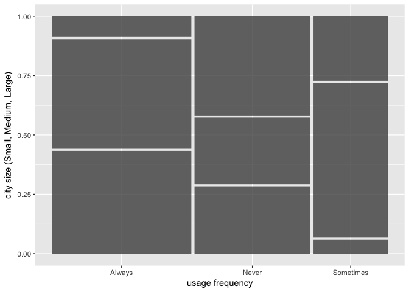

```r
q6_full_data %>% mutate(city_size = rownames(.)) %>%
  gather(Always, Sometimes, Never, key = 'usage_frequency', value = 'score') %>%
  ggplot() + geom_mosaic(aes(x = product(city_size, usage_frequency), weight = score)) +
  labs(x = 'usage frequency', y = 'city size (Small, Medium, Large)')
```

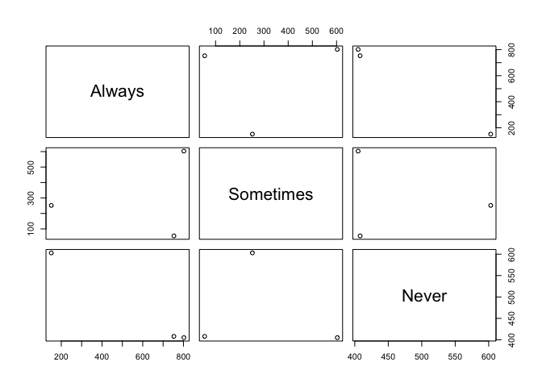

```r
q6_full_data %>% plot()
```

۷. شرکتی انتظار دارد با ارایه محصول الف میزان فروش محصول ب افزایش یابد. به همین منظور به طور تصادفی از صد مشتری خود اطلاعات مصرف جمع آوری می نماید. با توجه به داده های که داده شده آیا ربط معناداری بین فروش این دو محصول وجود دارد؟

> I’ve used Spearman’s correlation test for this test. the null hypothesis is that two variables are not correlated.  
> The resulting correlation coefficient states that our two variables are probably not related! and are independent!  
> The resulting p-value also proves that we cannot reject null hypothesis!  
> The point plot also helps providing a visualization of data distribution.  
> As it can be seen, there is no significant relation between two sets of data!

```r
############################################################################################################
# Q7

q7_data <- read_csv('data/consumption.csv')
q7_data %$% cor.test(.$A, .$B, method = 'spearman')
```

```
##
##  Spearman's rank correlation rho
##
## data:  .$A and .$B
## S = 160420, p-value = 0.7121
## alternative hypothesis: true rho is not equal to 0
## sample estimates:
##        rho
## 0.03736654
```

```r
q7_data %>% hchart(type = 'point', color = 'red', hcaes(x = A, y = B))
```

[interactive chart not shown]

۸. یک شرکت از ۲۰۰۰ نفر از مشتریان خود عامل خرید محصول را مورد سوال قرار میدهد که خلاصه اطلاعات آن را در زیر می توانید مشاهده کنید

| Characteristics | Male | Female |
| --- | --- | --- |
| Price | 301 | 502 |
| Design | 353 | 155 |
| Color | 558 | 153 |

آیا جنسیت تاثیری در مشخصه کاربری کالا دارد؟

> I’ve used non-parametric Pearson’s chi-squared test for this questin.  
> The null hypothesis is that customer’s gender has had no effect on product purchase motivation factor.  
> Resulting test p-values are small and way inside our confidence interval.  
> So it’s possible to say that the null hypothesis is wrong and customer’s gender has indeed an effect on product purchase motivation factore.  
> Mosaic chart’s asymeetric form also helps proving this point!

```r
############################################################################################################
# Q8

data.frame(row.names = c('Price', 'Design', 'Color'),
                      Male   = c(301, 353, 558),
                      Female = c(502, 155, 153)) -> q8_full_data

q8_full_data %>% chisq.test()
```

```
##
##  Pearson's Chi-squared test
##
## data:  .
## X-squared = 289.71, df = 2, p-value < 2.2e-16
```

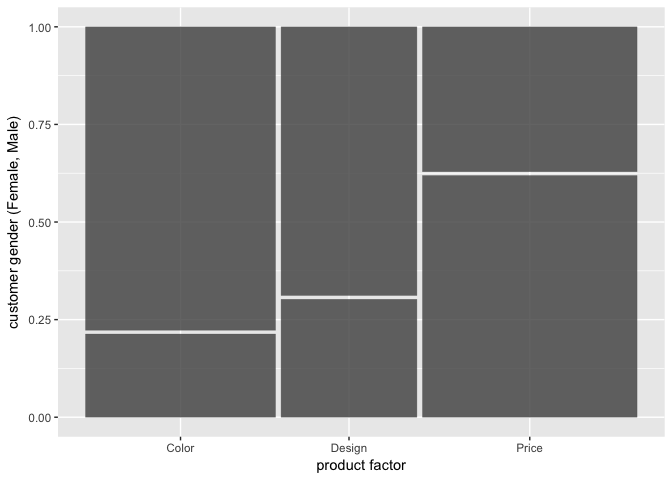

```r
q8_full_data %>% mutate(product_factor = rownames(.)) %>%
  gather(Male, Female, key = 'gender', value = 'count') %>%
  ggplot() + geom_mosaic(aes(x = product(gender, product_factor), weight = count)) +
  labs(y = 'customer gender (Female, Male)', x = 'product factor')
```